# Problem Statement

### Context

People watch movies for various reasons. Some for entertainment as in sports and action movies, for motivation and empowerment as in inspirational movies, others for the purposes of learning new things as in documentaries. The movie industry is a lucarative industry and has been growing steadily over the years. Internet Movie Database (IMDb) is an online database for movies, home videos, television series, etc. Users can post their ratings of movies on the site. People use the site to choose theirs movies of interest and decide on which movies are worth watching. As of March 2022, the database contained some 10.1 million titles (including television episodes) and 11.5 million person records. Additionally, the site had 83 million registered users.

### Objective

Carry out analysis on the imdb movies dataset to determine the following:

1. Factors that affects movie revenue
2. The popular genres of movies for each year
3. the growth of movie industry based on movies release by year

### Dataset Description

##### The dataset has the following information

##### id: id of the file

##### imdd_id : the imdb unique reference for the movie

##### popularity : popularity ratings for the movie

##### budget : the bugdet of the movie

##### revenue : revenue generated from the movie sales

##### original_title : title of the movie

##### cast : popular actors in the movie

##### homepage : Website for the movie

##### director : Name of the directors

##### tagline : movie tagline

##### overview : a brief description of the movie

##### runtime : duration of the moview in minutes

##### genres : the genres the movie falls into

##### production_company : Companies that produced the movie

##### release_date : date on which the movie was released

##### vote_count : total no of votes on the movie at the site

##### vote_average : an average of the vote counts

##### release_year : the year the movie was released

##### budget_adj : adjusted budget to cater for inflation

##### revenue_adj : adjusted revenue to cater for inflation

```python
# import modules and packages
import pandas as pd #for data manipulation and data analysis
import numpy as np #numerical computations
import matplotlib.pyplot as plt # data visualisation library
import seaborn as sns # data visualisation library

%matplotlib inline
```

```python
#read the dataset
df = pd.read_csv('tmdb-movies.csv')

# view first few rows of the dataset
df.head()
```

|  | id | imdb_id | popularity | budget | revenue | original_title | cast | homepage | director | tagline | ... | overview | runtime | genres | production_companies | release_date | vote_count | vote_average | release_year | budget_adj | revenue_adj |
| --- | --- | --- | --- | --- | --- | --- | --- | --- | --- | --- | --- | --- | --- | --- | --- | --- | --- | --- | --- | --- | --- |
| 0 | 135397 | tt0369610 | 32.985763 | 150000000 | 1513528810 | Jurassic World | Chris Pratt\|Bryce Dallas Howard\|Irrfan Khan\|Vi... | http://www.jurassicworld.com/ | Colin Trevorrow | The park is open. | ... | Twenty-two years after the events of Jurassic ... | 124 | Action\|Adventure\|Science Fiction\|Thriller | Universal Studios\|Amblin Entertainment\|Legenda... | 6/9/15 | 5562 | 6.5 | 2015 | 1.379999e+08 | 1.392446e+09 |
| 1 | 76341 | tt1392190 | 28.419936 | 150000000 | 378436354 | Mad Max: Fury Road | Tom Hardy\|Charlize Theron\|Hugh Keays-Byrne\|Nic... | http://www.madmaxmovie.com/ | George Miller | What a Lovely Day. | ... | An apocalyptic story set in the furthest reach... | 120 | Action\|Adventure\|Science Fiction\|Thriller | Village Roadshow Pictures\|Kennedy Miller Produ... | 5/13/15 | 6185 | 7.1 | 2015 | 1.379999e+08 | 3.481613e+08 |
| 2 | 262500 | tt2908446 | 13.112507 | 110000000 | 295238201 | Insurgent | Shailene Woodley\|Theo James\|Kate Winslet\|Ansel... | http://www.thedivergentseries.movie/#insurgent | Robert Schwentke | One Choice Can Destroy You | ... | Beatrice Prior must confront her inner demons ... | 119 | Adventure\|Science Fiction\|Thriller | Summit Entertainment\|Mandeville Films\|Red Wago... | 3/18/15 | 2480 | 6.3 | 2015 | 1.012000e+08 | 2.716190e+08 |
| 3 | 140607 | tt2488496 | 11.173104 | 200000000 | 2068178225 | Star Wars: The Force Awakens | Harrison Ford\|Mark Hamill\|Carrie Fisher\|Adam D... | http://www.starwars.com/films/star-wars-episod... | J.J. Abrams | Every generation has a story. | ... | Thirty years after defeating the Galactic Empi... | 136 | Action\|Adventure\|Science Fiction\|Fantasy | Lucasfilm\|Truenorth Productions\|Bad Robot | 12/15/15 | 5292 | 7.5 | 2015 | 1.839999e+08 | 1.902723e+09 |
| 4 | 168259 | tt2820852 | 9.335014 | 190000000 | 1506249360 | Furious 7 | Vin Diesel\|Paul Walker\|Jason Statham\|Michelle ... | http://www.furious7.com/ | James Wan | Vengeance Hits Home | ... | Deckard Shaw seeks revenge against Dominic Tor... | 137 | Action\|Crime\|Thriller | Universal Pictures\|Original Film\|Media Rights ... | 4/1/15 | 2947 | 7.3 | 2015 | 1.747999e+08 | 1.385749e+09 |

5 rows × 21 columns

```python
# show last few records of the dataset

df.tail()
```

|  | id | imdb_id | popularity | budget | revenue | original_title | cast | homepage | director | tagline | ... | overview | runtime | genres | production_companies | release_date | vote_count | vote_average | release_year | budget_adj | revenue_adj |
| --- | --- | --- | --- | --- | --- | --- | --- | --- | --- | --- | --- | --- | --- | --- | --- | --- | --- | --- | --- | --- | --- |
| 10861 | 21 | tt0060371 | 0.080598 | 0 | 0 | The Endless Summer | Michael Hynson\|Robert August\|Lord 'Tally Ho' B... | NaN | Bruce Brown | NaN | ... | The Endless Summer, by Bruce Brown, is one of ... | 95 | Documentary | Bruce Brown Films | 6/15/66 | 11 | 7.4 | 1966 | 0.000000 | 0.0 |
| 10862 | 20379 | tt0060472 | 0.065543 | 0 | 0 | Grand Prix | James Garner\|Eva Marie Saint\|Yves Montand\|Tosh... | NaN | John Frankenheimer | Cinerama sweeps YOU into a drama of speed and ... | ... | Grand Prix driver Pete Aron is fired by his te... | 176 | Action\|Adventure\|Drama | Cherokee Productions\|Joel Productions\|Douglas ... | 12/21/66 | 20 | 5.7 | 1966 | 0.000000 | 0.0 |
| 10863 | 39768 | tt0060161 | 0.065141 | 0 | 0 | Beregis Avtomobilya | Innokentiy Smoktunovskiy\|Oleg Efremov\|Georgi Z... | NaN | Eldar Ryazanov | NaN | ... | An insurance agent who moonlights as a carthie... | 94 | Mystery\|Comedy | Mosfilm | 1/1/66 | 11 | 6.5 | 1966 | 0.000000 | 0.0 |
| 10864 | 21449 | tt0061177 | 0.064317 | 0 | 0 | What's Up, Tiger Lily? | Tatsuya Mihashi\|Akiko Wakabayashi\|Mie Hama\|Joh... | NaN | Woody Allen | WOODY ALLEN STRIKES BACK! | ... | In comic Woody Allen's film debut, he took the... | 80 | Action\|Comedy | Benedict Pictures Corp. | 11/2/66 | 22 | 5.4 | 1966 | 0.000000 | 0.0 |
| 10865 | 22293 | tt0060666 | 0.035919 | 19000 | 0 | Manos: The Hands of Fate | Harold P. Warren\|Tom Neyman\|John Reynolds\|Dian... | NaN | Harold P. Warren | It's Shocking! It's Beyond Your Imagination! | ... | A family gets lost on the road and stumbles up... | 74 | Horror | Norm-Iris | 11/15/66 | 15 | 1.5 | 1966 | 127642.279154 | 0.0 |

5 rows × 21 columns

# Data Wrangling Phase

```python
# Check dimensions of the dataset
df.shape
```

```
(10866, 21)
```

There are 10866 rows and 21 columns

```python
# check the size of the dataset
df.size
```

```
228186
```

The size is the product of the rows and columns. It shows the individual elements in the dataset

```python
# check datatypes in the dataset
df.info()
```

```
<class 'pandas.core.frame.DataFrame'>
RangeIndex: 10866 entries, 0 to 10865
Data columns (total 21 columns):
 #   Column                Non-Null Count  Dtype
---  ------                --------------  -----
 0   id                    10866 non-null  int64
 1   imdb_id               10856 non-null  object
 2   popularity            10866 non-null  float64
 3   budget                10866 non-null  int64
 4   revenue               10866 non-null  int64
 5   original_title        10866 non-null  object
 6   cast                  10790 non-null  object
 7   homepage              2936 non-null   object
 8   director              10822 non-null  object
 9   tagline               8042 non-null   object
 10  keywords              9373 non-null   object
 11  overview              10862 non-null  object
 12  runtime               10866 non-null  int64
 13  genres                10843 non-null  object
 14  production_companies  9836 non-null   object
 15  release_date          10866 non-null  object
 16  vote_count            10866 non-null  int64
 17  vote_average          10866 non-null  float64
 18  release_year          10866 non-null  int64
 19  budget_adj            10866 non-null  float64
 20  revenue_adj           10866 non-null  float64
dtypes: float64(4), int64(6), object(11)
memory usage: 1.7+ MB
```

The datatypes are distributed as follows: float - 4 integer - 6 object - 11

There are 10866 rows in the dataset. Some columns appear to have missing values. We will explore further

```python
# check for missing values by column
df.isna().sum().sort_values(ascending=False)
```

```
homepage                7930
tagline                 2824
keywords                1493
production_companies    1030
cast                      76
director                  44
genres                    23
imdb_id                   10
overview                   4
budget_adj                 0
release_year               0
vote_average               0
vote_count                 0
release_date               0
id                         0
runtime                    0
original_title             0
revenue                    0
budget                     0
popularity                 0
revenue_adj                0
dtype: int64
```

```python
df.drop(['homepage', 'keywords', 'tagline', 'production_companies', 'overview', 'cast', 'director', 'imdb_id'], axis=1, inplace=True)
```

```python
df.info()
```

```
<class 'pandas.core.frame.DataFrame'>
RangeIndex: 10866 entries, 0 to 10865
Data columns (total 13 columns):
 #   Column          Non-Null Count  Dtype
---  ------          --------------  -----
 0   id              10866 non-null  int64
 1   popularity      10866 non-null  float64
 2   budget          10866 non-null  int64
 3   revenue         10866 non-null  int64
 4   original_title  10866 non-null  object
 5   runtime         10866 non-null  int64
 6   genres          10843 non-null  object
 7   release_date    10866 non-null  object
 8   vote_count      10866 non-null  int64
 9   vote_average    10866 non-null  float64
 10  release_year    10866 non-null  int64
 11  budget_adj      10866 non-null  float64
 12  revenue_adj     10866 non-null  float64
dtypes: float64(4), int64(6), object(3)
memory usage: 1.1+ MB
```

There are still missing values for Genre. We will replace these values with the frequently occuring Genre

```python
# Finding the frequently occuring movie Genre
# Genres
df.genres.value_counts()
```

```
Comedy                                      712
Drama                                       712
Documentary                                 312
Drama|Romance                               289
Comedy|Drama                                280
                                           ...
Adventure|Animation|Romance                   1
Family|Animation|Drama                        1
Action|Adventure|Animation|Comedy|Family      1
Action|Adventure|Animation|Fantasy            1
Mystery|Science Fiction|Thriller|Drama        1
Name: genres, Length: 2039, dtype: int64
```

```python
# indivual Genres
# Which genre features more in the genre list
genre_data = dict()
exceptions = []
for genre in df.genres:
    try:
        for g in genre.split('|'):
            #print(g)
            if g in genre_data:
                genre_data[g] +=1
            else:
                genre_data[g] = 1
    except:
        exceptions.append(genre)

genre_data
```

```
{'Action': 2385,
 'Adventure': 1471,
 'Science Fiction': 1230,
 'Thriller': 2908,
 'Fantasy': 916,
 'Crime': 1355,
 'Western': 165,
 'Drama': 4761,
 'Family': 1231,
 'Animation': 699,
 'Comedy': 3793,
 'Mystery': 810,
 'Romance': 1712,
 'War': 270,
 'History': 334,
 'Music': 408,
 'Horror': 1637,
 'Documentary': 520,
 'TV Movie': 167,
 'Foreign': 188}
```

```python
# Fill missing genres with Comedy
df.genres.fillna('Comedy', inplace=True)
```

```python
df.info()
```

```
<class 'pandas.core.frame.DataFrame'>
RangeIndex: 10866 entries, 0 to 10865
Data columns (total 13 columns):
 #   Column          Non-Null Count  Dtype
---  ------          --------------  -----
 0   id              10866 non-null  int64
 1   popularity      10866 non-null  float64
 2   budget          10866 non-null  int64
 3   revenue         10866 non-null  int64
 4   original_title  10866 non-null  object
 5   runtime         10866 non-null  int64
 6   genres          10866 non-null  object
 7   release_date    10866 non-null  object
 8   vote_count      10866 non-null  int64
 9   vote_average    10866 non-null  float64
 10  release_year    10866 non-null  int64
 11  budget_adj      10866 non-null  float64
 12  revenue_adj     10866 non-null  float64
dtypes: float64(4), int64(6), object(3)
memory usage: 1.1+ MB
```

```python
df.isna().sum().sum()
```

```
0
```

There are no missing values in our dataset. We have successfully dealt with all of them

```python
#Summary Statistics
df.describe().T
```

|  | count | mean | std | min | 25% | 50% | 75% | max |
| --- | --- | --- | --- | --- | --- | --- | --- | --- |
| id | 10866.0 | 6.606418e+04 | 9.213014e+04 | 5.000000 | 10596.250000 | 20669.000000 | 7.561000e+04 | 4.178590e+05 |
| popularity | 10866.0 | 6.464410e-01 | 1.000185e+00 | 0.000065 | 0.207583 | 0.383856 | 7.138170e-01 | 3.298576e+01 |
| budget | 10866.0 | 1.462570e+07 | 3.091321e+07 | 0.000000 | 0.000000 | 0.000000 | 1.500000e+07 | 4.250000e+08 |
| revenue | 10866.0 | 3.982332e+07 | 1.170035e+08 | 0.000000 | 0.000000 | 0.000000 | 2.400000e+07 | 2.781506e+09 |
| runtime | 10866.0 | 1.020709e+02 | 3.138141e+01 | 0.000000 | 90.000000 | 99.000000 | 1.110000e+02 | 9.000000e+02 |
| vote_count | 10866.0 | 2.173897e+02 | 5.756191e+02 | 10.000000 | 17.000000 | 38.000000 | 1.457500e+02 | 9.767000e+03 |
| vote_average | 10866.0 | 5.974922e+00 | 9.351418e-01 | 1.500000 | 5.400000 | 6.000000 | 6.600000e+00 | 9.200000e+00 |
| release_year | 10866.0 | 2.001323e+03 | 1.281294e+01 | 1960.000000 | 1995.000000 | 2006.000000 | 2.011000e+03 | 2.015000e+03 |
| budget_adj | 10866.0 | 1.755104e+07 | 3.430616e+07 | 0.000000 | 0.000000 | 0.000000 | 2.085325e+07 | 4.250000e+08 |
| revenue_adj | 10866.0 | 5.136436e+07 | 1.446325e+08 | 0.000000 | 0.000000 | 0.000000 | 3.369710e+07 | 2.827124e+09 |

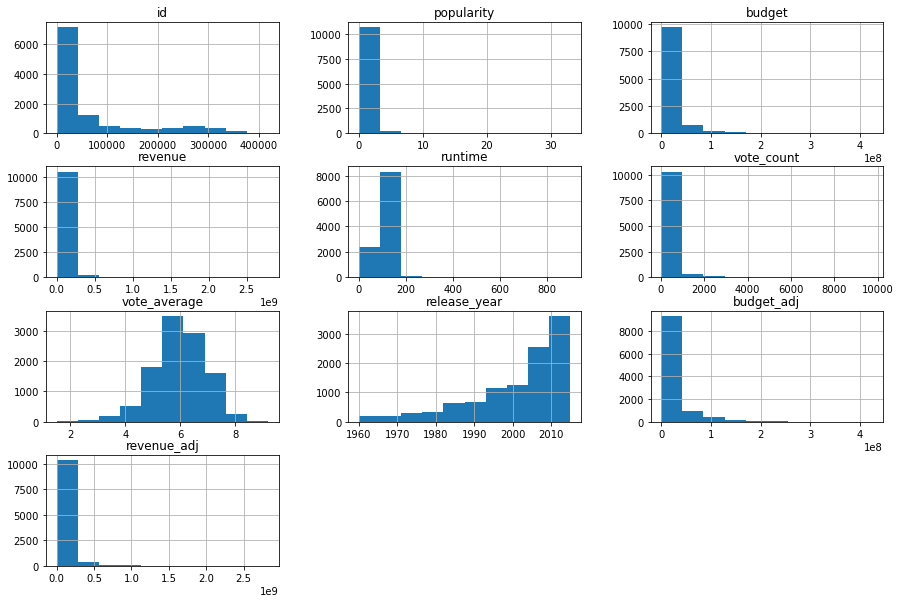

```python
#Distribution of the various variables

df.hist(figsize=(15,10));
```

The release_year histogram is skewed to the left. we see a rise in the number of movies released yearly. The average vote follows a normal distribution.

# Explore Factors that affect revenue

```python
#separate data into categorical and numerical columns
numerical_cols = [df.columns[i] for i in range(len(df.columns)) if df.dtypes[i] !='object']
categorical_cols = [df.columns[i] for i in range(len(df.columns)) if df.dtypes[i] =='object']
```

Separating data into categorical and numerical sets informs the kind of analysis to perform on each variable. We can look at boxplots for outliers and scatter plots for linear relationships amongst the numerical variables

```python
# define a scatter plot function
def display_scatterplot(x, y, xlabel, ylabel, title):
    '''
    Draw a scatter plot with the following input variables x, y.
    This plot shows the relationship between two numerical variables

    xlabel and ylabel are the labels for the x and y values respectively
    title : the title of the plot

    '''

    plt.scatter(x, y)
    plt.xlabel(xlabel)
    plt.ylabel(ylabel)
    plt.title(title)
    plt.show()
```

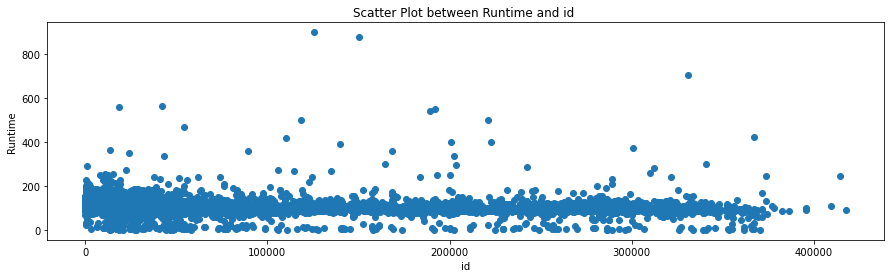

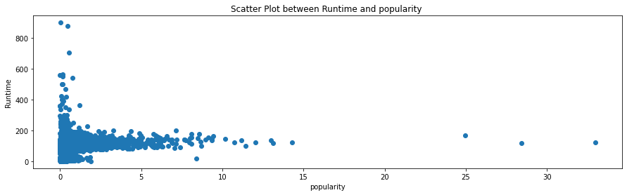

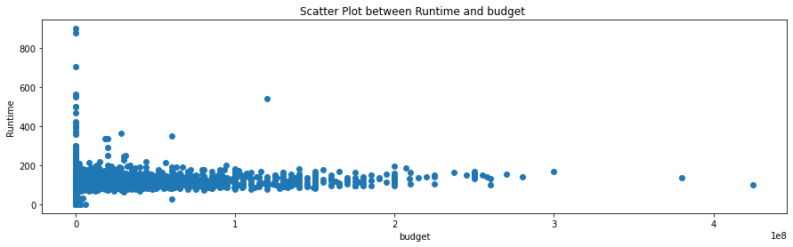

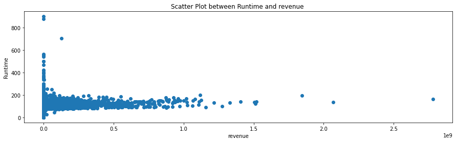

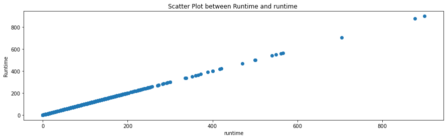

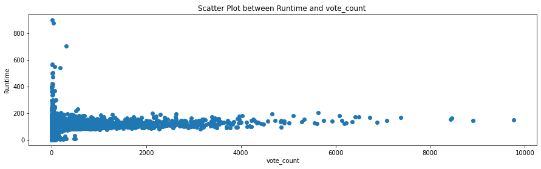

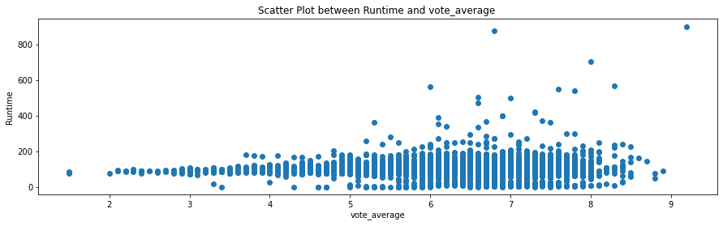

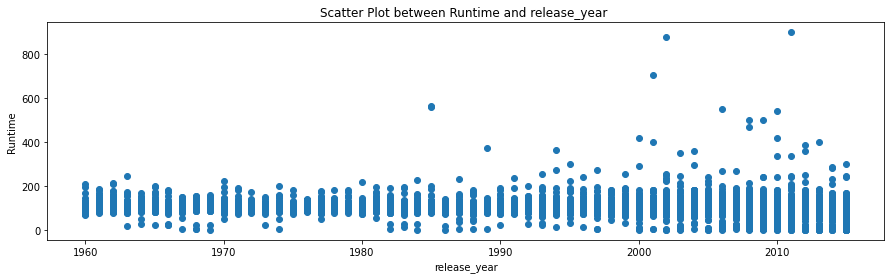

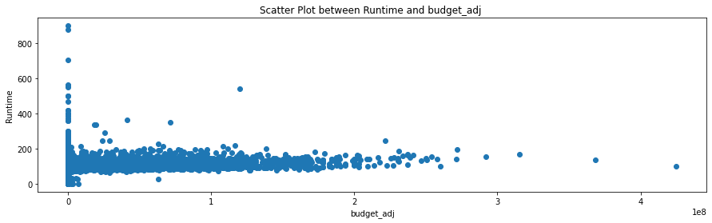

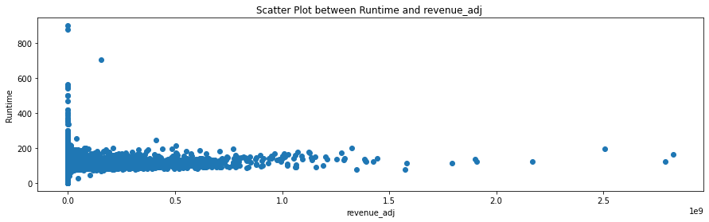

```python
# Anaylse runtime with the other categorical values
for i in range(len(numerical_cols)):
    plt.figure(figsize=(15,4))
    y = df.runtime
    x = df[numerical_cols[i]]
    sp_title = f'Scatter Plot between Runtime and {numerical_cols[i]} '
    print('\n')
    display_scatterplot(x,y, ylabel='Runtime', xlabel=str(numerical_cols[i]), title=sp_title)
    plt.show()
```

Observation : The runtime is not dependent on the release year. Movies release in the 1960s have similar runtimes with those release post 2010s.

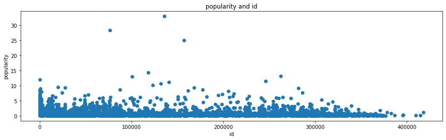

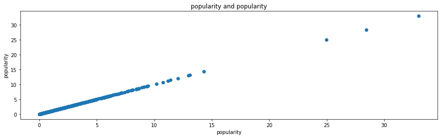

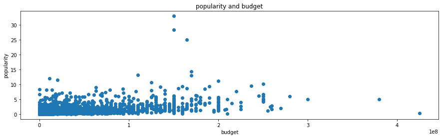

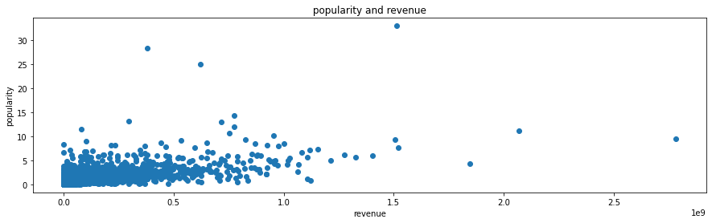

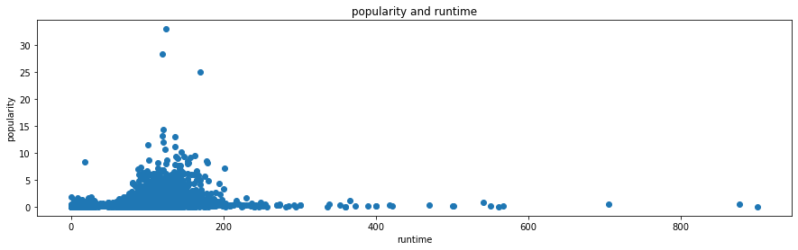

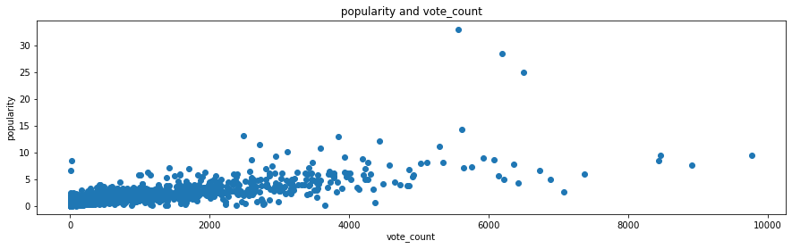

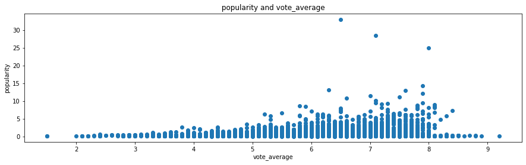

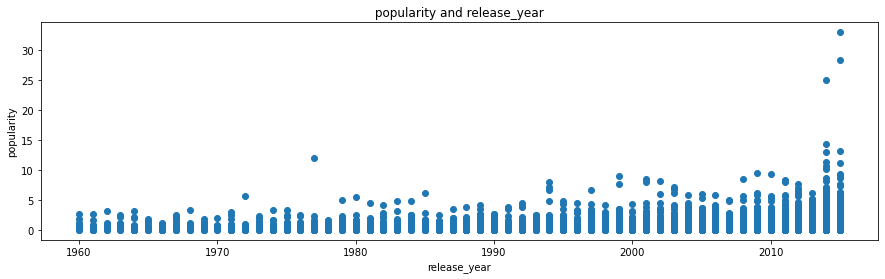

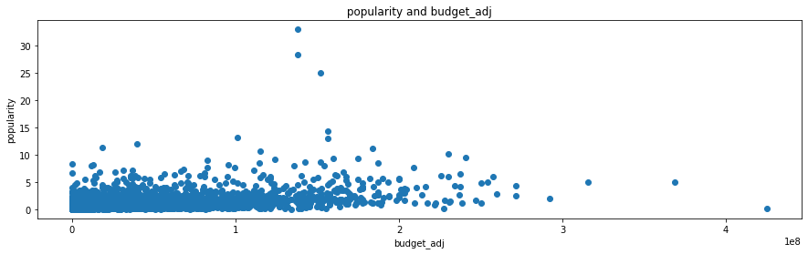

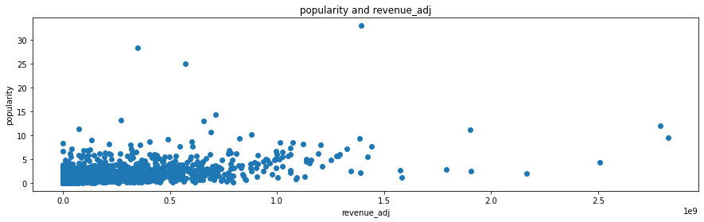

```python
#Analyse popularity along with other numerical columns
for i in range(len(numerical_cols)):
    plt.figure(figsize=(15,4))
    y = df.popularity
    x = df[numerical_cols[i]]
    sp_title = f' popularity and {numerical_cols[i]} '
    print('\n')
    display_scatterplot(x,y, ylabel='popularity', xlabel=str(numerical_cols[i]), title=sp_title)
    plt.show()
```

Observation : The more popular a movie is the higher the vote count. Similarly, more popular movies record more revenue. Movies with less runtime typically below 200 minutes are more popular than those above 200. We can deduce that people loose interest in longer running movies.

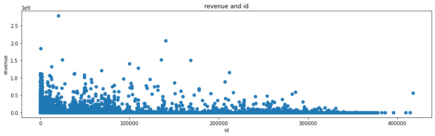

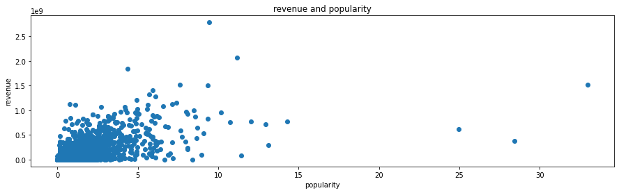

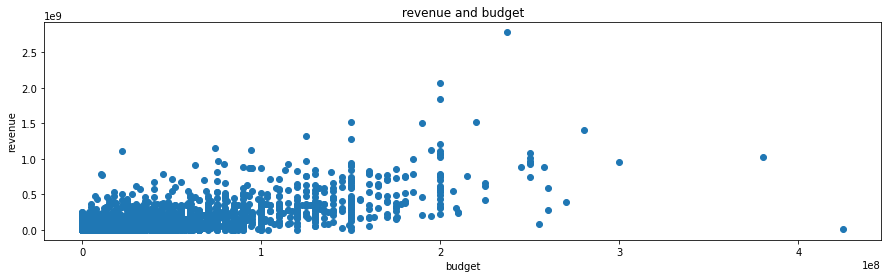

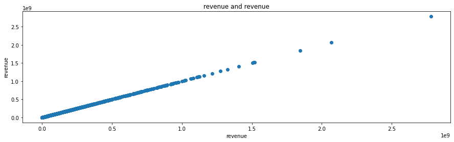

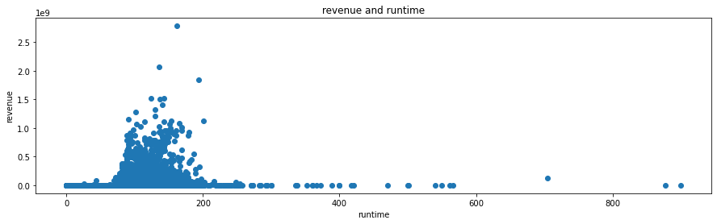

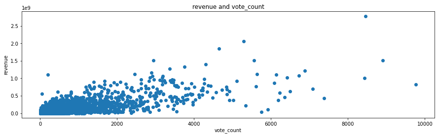

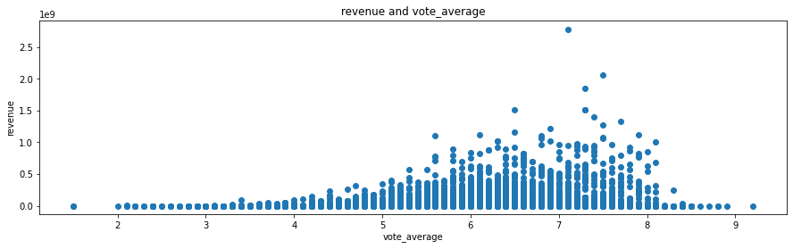

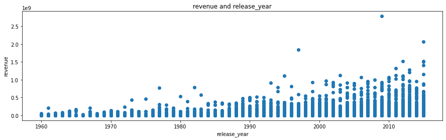

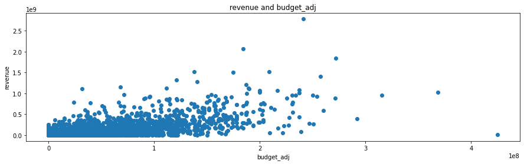

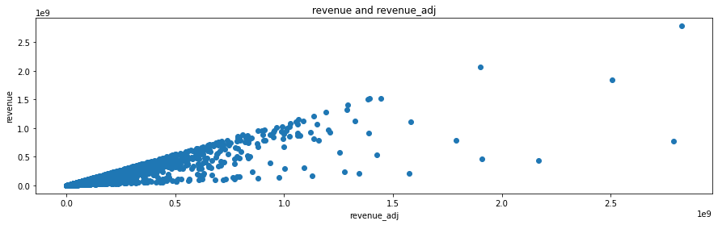

```python
# Compare Revenue with the other numerical values
for i in range(len(numerical_cols)):
    plt.figure(figsize=(15,4))
    y = df.revenue
    x = df[numerical_cols[i]]
    sp_title = f' revenue and {numerical_cols[i]} '
    print('\n')
    display_scatterplot(x,y, ylabel='revenue', xlabel=str(numerical_cols[i]), title=sp_title)
    plt.show()
```

Observation: As budget rise, the revenue also rises. This mean that highly budgeted movies are more likely to generate high revenues. We saw in the previous analysis that movies with less runtime are more popular, here we see that movies with less runtime also generate high revenue. This implies that runtime and popularity have an effect on revenue.

# Explore release year

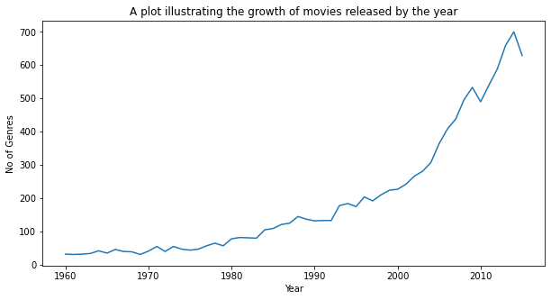

```python
# Group data by release year
rel_year = df.groupby(['release_year'])['genres'].count()


#plot a line chart to illustrate the data above
plt.figure(figsize=(10,5))
rel_year.plot()
plt.xlabel('Year')
plt.ylabel('No of Genres')
plt.title('A plot illustrating the growth of movies released by the year')
plt.show()
```

Observation : The number of movies released year on year has been growing steadily from 1960s till mid 2010s. This indicates a thriving movie industry

```python
# Most Popular Movies
# Top five popular movies
top_five = df[df['popularity'] >= df.popularity.mean()].head()[['original_title', 'popularity']]
```

```python
print(top_five.original_title)
```

```
0                  Jurassic World
1              Mad Max: Fury Road
2                       Insurgent
3    Star Wars: The Force Awakens
4                       Furious 7
Name: original_title, dtype: object
```

The most popular movie is Jurassic World

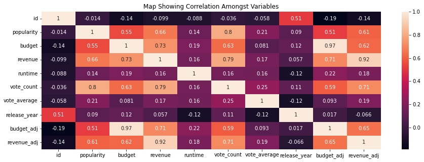

```python
# Correlation amongst variables
plt.figure(figsize=(15,5))
sns.heatmap(df.corr(), annot=True)
plt.title('Map Showing Correlation Amongst Variables')
plt.show()
```

Budget and Popularity affects positively impacts Revenue

```
Pair plot showing relationship between budget, revenue and popularity
```

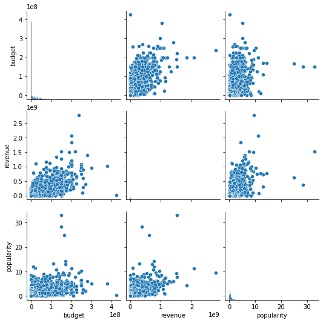

```python
print ('Pair plot showing relationship between budget, revenue and popularity')
sns.pairplot(data=df, vars=['budget', 'revenue', 'popularity'])
plt.show()
```

The pairplot buttresses the observations made earlier about the positive effect of popularity and budget on revenue.

# Conclusion

The exploratory data analysis showed what really impact revenue for movies. It also show that the movie industry is growing and as more and more movies are being released each year. As people's interest in a movie grows, it's popularity also grows. The vote count can be used to determine the popularity of the movie. As a movie becomes popular, it turns to generate more revenue. Although correlation does not always imply causation, the data available seems to strongly suggest that popularity, budget and vote count have a strong effect on the revenue.

The columns dropped had no effect on the analysis. The genres were grouped together, this made it challenging to clearly show the effect the genres have on the popularity of the movie.